# Modelos Arma

## Série 7

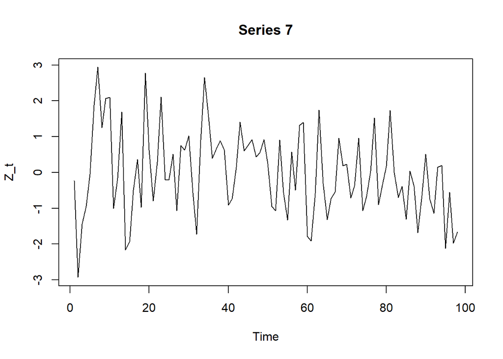

```r
plot(X[[7]], main = "Series 7", ylab = "Z_t")
```

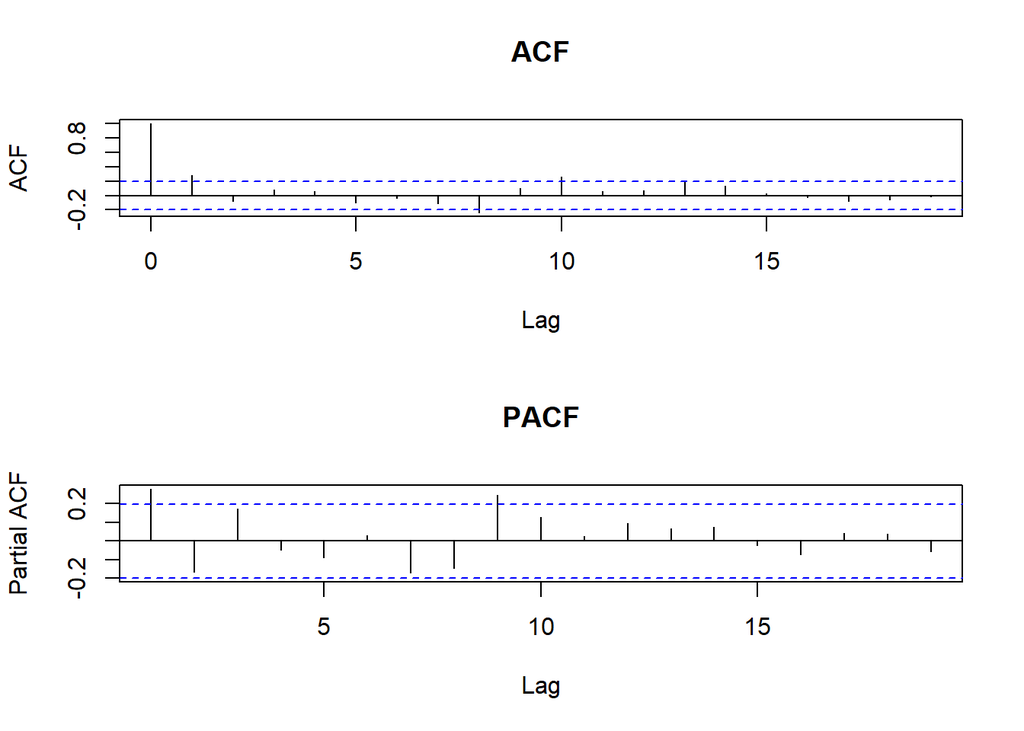

```r
plot_acf_pacf(X[[7]])
```

O ACF decai rapidamente para lag maior do que $1$, enquanto que o PACF decresce bem lentamente, o que indica que o modelo MA(1) é uma boa escolha aqui.

```r
model7 <- arma(X[[7]], order = c(0, 1))
summary(model7)
```

```
##
## Call:
## arma(x = X[[7]], order = c(0, 1))
##
## Model:
## ARMA(0,1)
##
## Residuals:
##      Min       1Q   Median       3Q      Max
## -2.90811 -0.83574  0.09345  0.65703  3.23671
##
## Coefficient(s):
##            Estimate  Std. Error  t value Pr(>|t|)
## ma1         0.39365     0.10095    3.900 9.64e-05 ***
## intercept  -0.01875     0.15811   -0.119    0.906
## ---
## Signif. codes:  0 '***' 0.001 '**' 0.01 '*' 0.05 '.' 0.1 ' ' 1
##
## Fit:
## sigma^2 estimated as 1.282,  Conditional Sum-of-Squares = 123.1,  AIC = 306.47
```

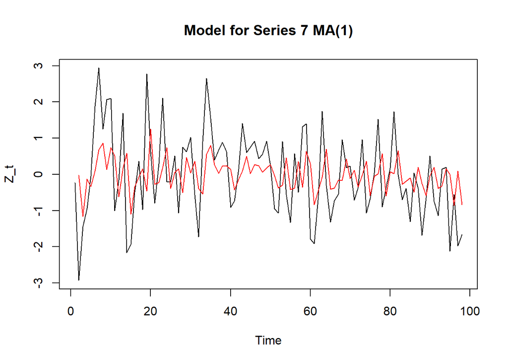

```r
plot(X[[7]], main = "Model for Series 7 MA(1)", ylab = "Z_t")
lines(model7$fitted.values, col = "red")
```

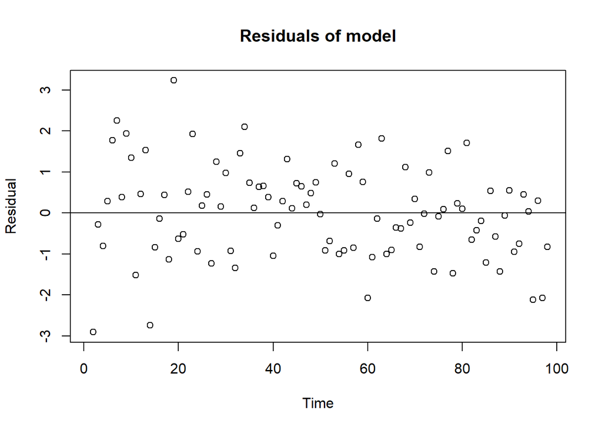

```r
plot_res(model7$residuals)
```

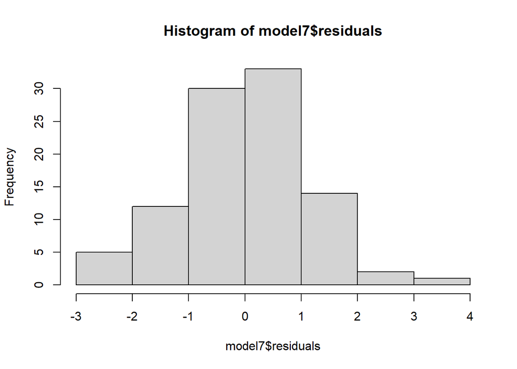

```r
hist(model7$residuals)
```

O modelo se enccaixou razoavelmente aos dados, mas não capturou bem os picos apresentados.

## Série 8

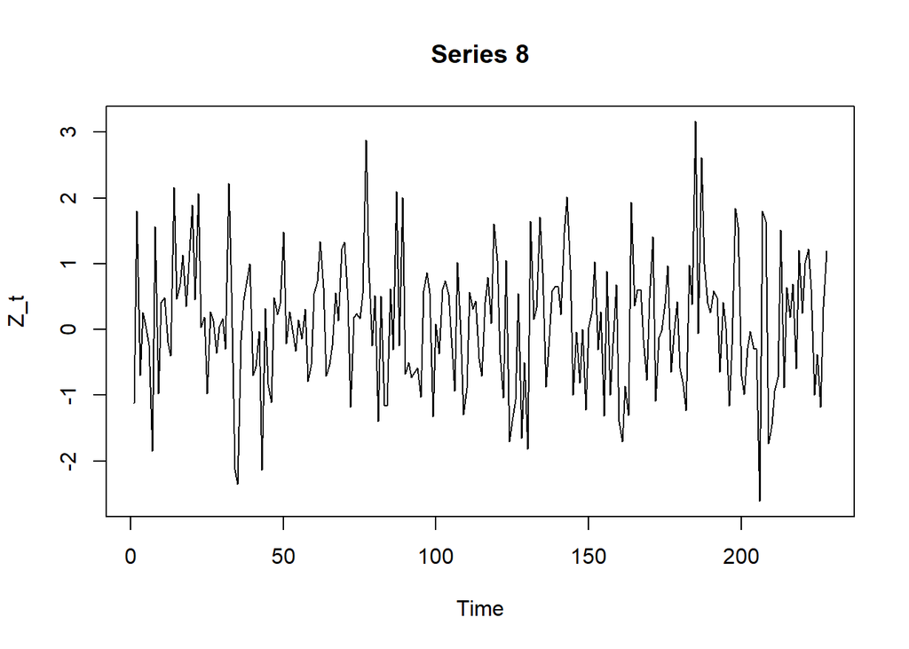

```r
plot(X[[8]], main = "Series 8", ylab = "Z_t")
```

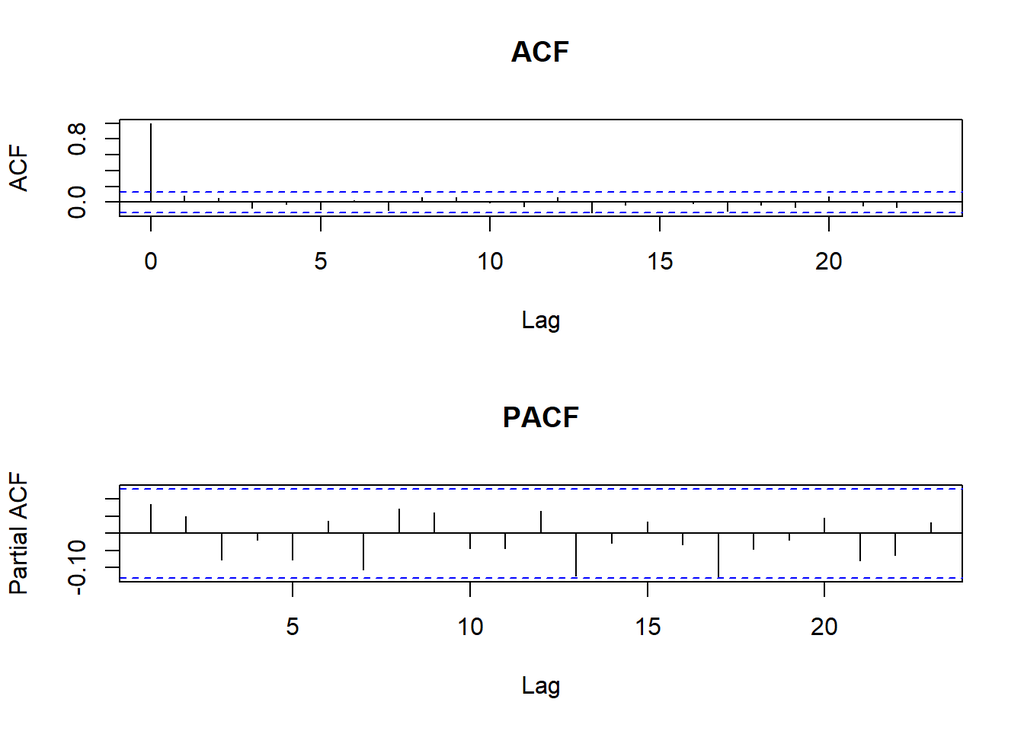

```r
plot_acf_pacf(X[[8]])
```

Tanto ACF quanto PACF são bem pequenas para lag maiores que zero, indicando que é um ruído branco.

```r
data.frame(mean = mean(X[[8]]), variance = var(X[[8]])*227/228)
```

```
##         mean variance
## 1 0.09216291 0.996732
```

Temos que $E(a_t)=0$ e $Var(a_t) = 1$, o que indica que o modelo se comporta como um ruído branco. Gerarmos $228$ amostras de $a_t$ e visualizarmos tanto o modelo e predição, quanto o residual:

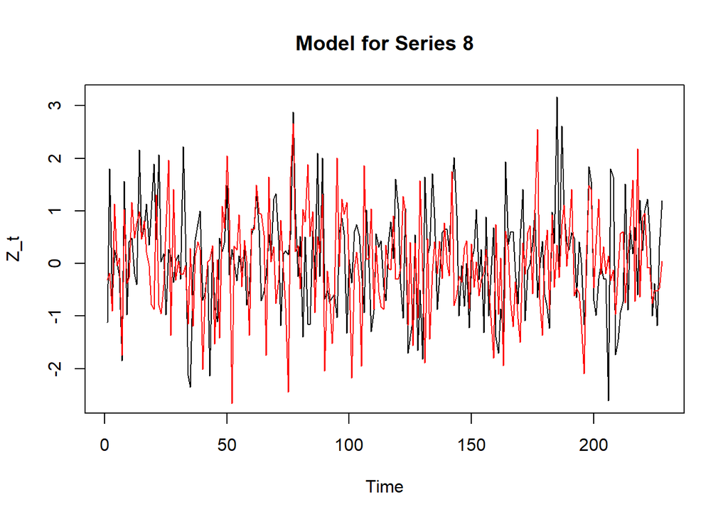

```r
model8 <- rnorm(228)
plot(X[[8]], main = "Model for Series 8", ylab = "Z_t")
lines(model8, col = "red")
```

```r
model8$residual <- X[[8]] - model8
```

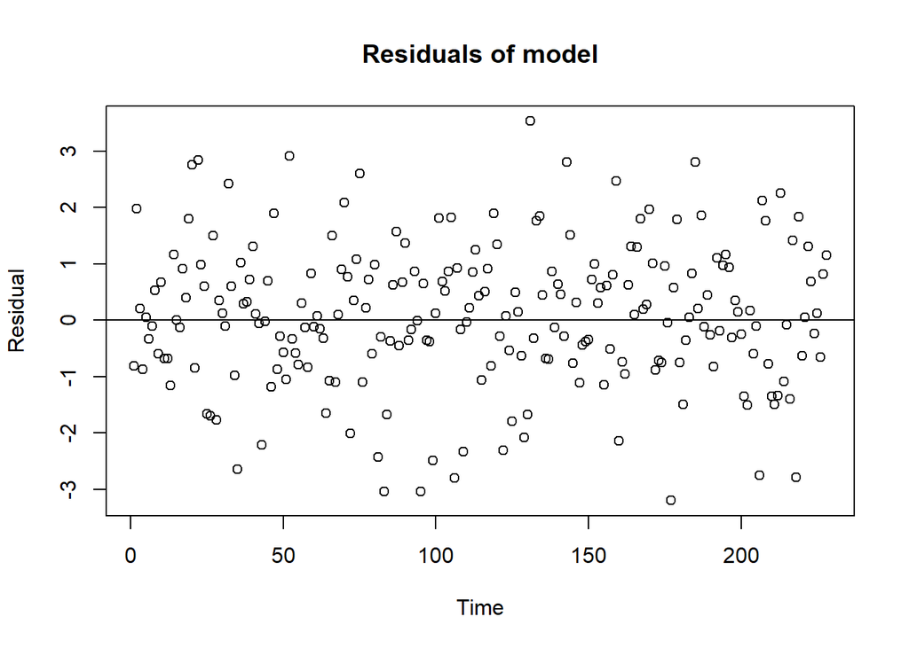

```r
plot_res(model8$residual)
```

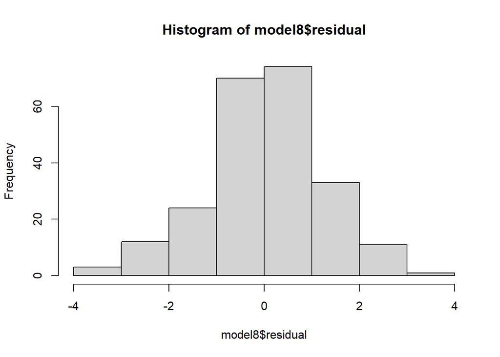

```r
hist(model8$residual)
```

## Série 9

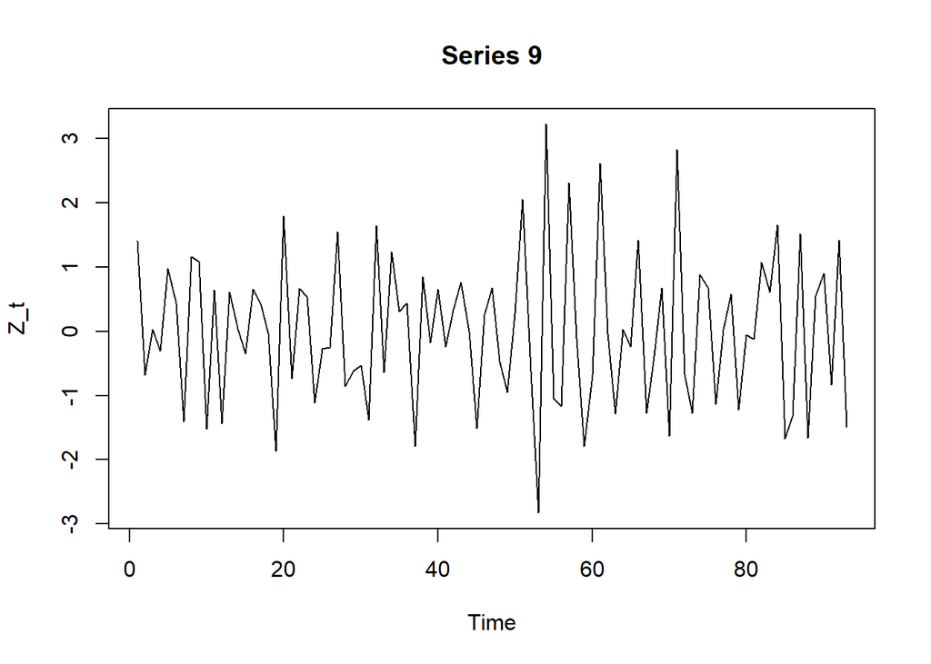

```r
plot(X[[9]], main = "Series 9", ylab = "Z_t")
```

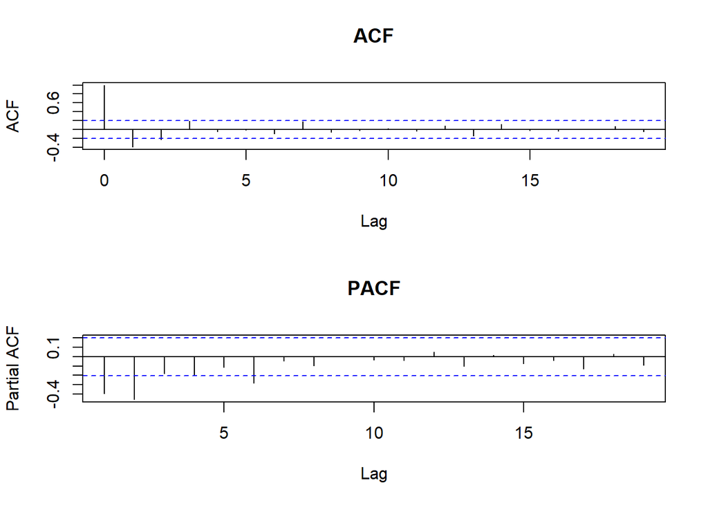

```r
plot_acf_pacf(X[[9]])
```

O ACF decai rapidamente para lag maior do que $1$, equanto que o PACF decai mais lentamente para lag maior do que $1$. Assim, testaremos os modelos MA(1) e ARMA(1,1).

```r
model9 <- arma(X[[9]], order = c(0, 1))
summary(model9)
```

```
##
## Call:
## arma(x = X[[9]], order = c(0, 1))
##
## Model:
## ARMA(0,1)
##
## Residuals:
##     Min      1Q  Median      3Q     Max
## -2.5405 -0.6815 -0.1173  0.5474  2.3902
##
## Coefficient(s):
##            Estimate  Std. Error  t value Pr(>|t|)
## ma1       -0.969369    0.038766  -25.006   <2e-16 ***
## intercept -0.002035    0.004299   -0.473    0.636
## ---
## Signif. codes:  0 '***' 0.001 '**' 0.01 '*' 0.05 '.' 0.1 ' ' 1
##
## Fit:
## sigma^2 estimated as 0.7455,  Conditional Sum-of-Squares = 68.05,  AIC = 240.61
```

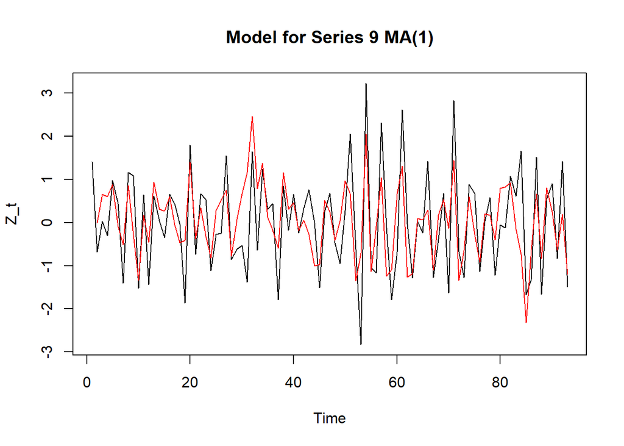

```r
plot(X[[9]], main = "Model for Series 9 MA(1)", ylab = "Z_t")
lines(model9$fitted.values, col = "red")
```

```r
model9_2 <- arma(X[[9]], order = c(1, 1))
summary(model9_2)
```

```
##
## Call:
## arma(x = X[[9]], order = c(1, 1))
##
## Model:
## ARMA(1,1)
##
## Residuals:
##       Min        1Q    Median        3Q       Max
## -2.156261 -0.544383  0.003433  0.651768  2.085140
##
## Coefficient(s):
##            Estimate  Std. Error  t value Pr(>|t|)
## ar1       -0.274298          NA       NA       NA
## ma1       -1.094195          NA       NA       NA
## intercept  0.001394          NA       NA       NA
##
## Fit:
## sigma^2 estimated as 0.6787,  Conditional Sum-of-Squares = 61.76,  AIC = 233.87
```

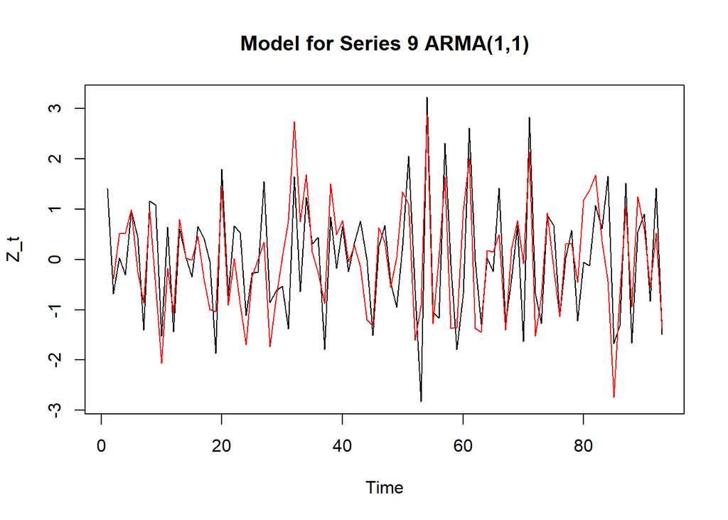

```r
plot(X[[9]], main = "Model for Series 9 ARMA(1,1)", ylab = "Z_t")
lines(model9_2$fitted.values, col = "red")
```

Tivemos que o modelo ARMA(1,1) apresentou AIC menor que o modelo MA(1), além de aparentar visualmente se encaixar um pouco melhor nos dados.

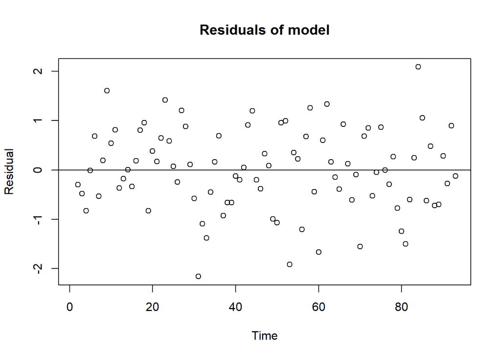

```r
plot_res(model9_2$residuals)
```

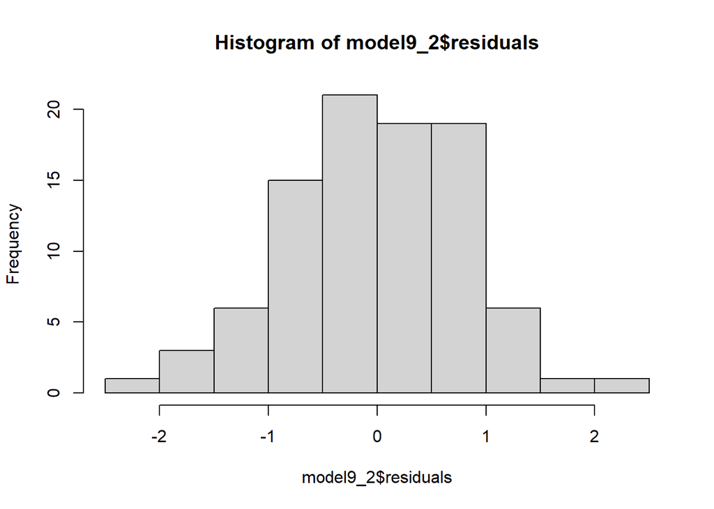

```r
hist(model9_2$residuals)
```

O modelo se encaixou bem aos dados, conseguindo capturar razoavelmente os picos.